# Beer and peanuts example

Kiyoshi YONEDA

2015-08-02 – 2015-09-22

# 1 Prepare the solver

To build the conversion and related programas you go like this:

```r
library(knitr)
purl("armax.Rmd"     , output = "armax.R"     , documentation = 1)
purl("armax-plot.Rmd", output = "armax-plot.R", documentation = 1)
purl("armax-cd.Rmd"  , output = "armax-cd.R"  , documentation = 1)
```

Assume the above has been done. To load `armax.R` and related programas do

```r
source("armax.R") # solution progs
```

# 2 Build the model to solve

## 2.1 Problem

You wish to drink beer eating roasted peanuts. There is a desired beer-to-peanuts ratio. You are willing to pay a certain amount of money, but not too much. You accept to gain some weight, but not too much, either. How much should you eat and drink? Should you do that at all?

## 2.2 Formulation

The items to consider are:

- `beer` in *ml*, milliliters
- `peanuts` in *g* , grams
- `ratio` of beer to peanuts in *ml/g*
- `cost` in *yen*
- `energy` in *kcal*, kilocalories

For each item you need two pieces of information:

- a criterion to judge how desirable the value is when considerig only this item;
- a causality function describing how values of other items affect the value of this item.

### 2.2.1 Beer

First, make a data structure template for beer.

```r
(beer <- template.item("beer"))
```

```
## $chr
## [1] "beer"
##
## $unit
## [1] "[]"
##
## $tab
##   y     p
## 1 0 0.001
## 2 1 1.000
## 3 0 0.001
##
## $caus
## function (y)
## y[chr]
## <environment: 0x7fdb5444b898>
```

The structure consists of:

- `$chr`: name in characters
- `$unit`: measurement unit
- `$tab`: table consisting of
  - `y`: value of the item
  - `p`: corresponding desirability of the value, $0 \le p \le 1$
- `caus`: causality relating values of other items to the value of this item

`y` and `p` in `$tab` define how desirable the amount `y` of beer is. The largest value of `p`, which is 1 in this case, means that if the amount `y` of beer is 350 ml, then the decision maker takes the action of drinking the beer with probability 1 when all other items have desirability of 1. The value `rare` for `y` $= 200$ means that if the amount of beer is only 200 ml, the decision maker is unlikely to take the trouble to drink the beer even when the desirability of all other items is 1. Likewise, she doesn’t want to drink more then 900 ml beer.

For 300 ml of beer, she takes the action with probability 0.9 when the desirability of all other items is 1. For 450 and 500 ml, the probability is 0.8 and 0.6, respectively.

```r
beer$unit <- "[ml]"
#beer$grade <- TRUE
beer$tab <- data.frame(y = c( 200, 300, 350, 450, 500, 900 ),
                       p = c(rare,  .9,   1,  .8,  .6, rare))
beer$caus <- function(y) y["beer"]
beer <- init.item(beer)
```

The causality `caus` in this case is the quantity of beer itself

$y_{\text{beer}} := y_{\text{beer}} \quad \text{[ml]}$

refrecting the perception that one of the outcomes of drinking beer is that you have drunk the beer. To drink the beer, which is the cause, is on the right hand side of the equation, whereas the same as an outcome is on the left. In other words, the causality relationship between the amout of beer drunk as action and the amount of beer drunk as an outcome is the identity transformation: the cause by itself consists a part of the outcomes.

The last line with `init.item` sets up auxiliary tables which will be necessary to reduce the problem to the least squares. It results in a structure such as:

```r
beer
```

```
## $chr
## [1] "beer"
##
## $unit
## [1] "[ml]"
##
## $tab
##     y     p         l          z       a0        a1
## 1 200 0.001 6.9077553 -2.6282609 314.0903  43.40903
## 2 300 0.900 0.1053605 -0.3245928 350.0000 154.03913
## 3 350 1.000 0.0000000  0.0000000 350.0000 211.69365
## 4 450 0.800 0.2231436  0.4723807 352.5376 206.32175
## 5 500 0.600 0.5108256  0.7147207 350.5972 209.03663
## 6 900 0.001 6.9077553  2.6282609       NA        NA
##
## $caus
## function (y)
## y["beer"]
```

The details of `$tab` are:

- `y`: amout of beer in ml
- `p`: desirability of `y`
- `l`: $- \log p$
- `z`: normalized `y`; if $y < \max [\cdots, y_i, \cdots]$ then $- l^{1/2}$ else $l^{1/2}$
- `a0`, `a1`: coefficients which define the linear bijection between `z` and `y`

This is easier to read:

```r
print.item(beer)
```

```
## beer [ml]
##     y     z   p    l     a0     a1
## 1 200 -2.63 0.0 6.91 314.09  43.41
## 2 300 -0.32 0.9 0.11 350.00 154.04
## 3 350  0.00 1.0 0.00 350.00 211.69
## 4 450  0.47 0.8 0.22 352.54 206.32
## 5 500  0.71 0.6 0.51 350.60 209.04
## 6 900  2.63 0.0 6.91     NA     NA
## caus = function(y) y["beer"]
```

The dots in

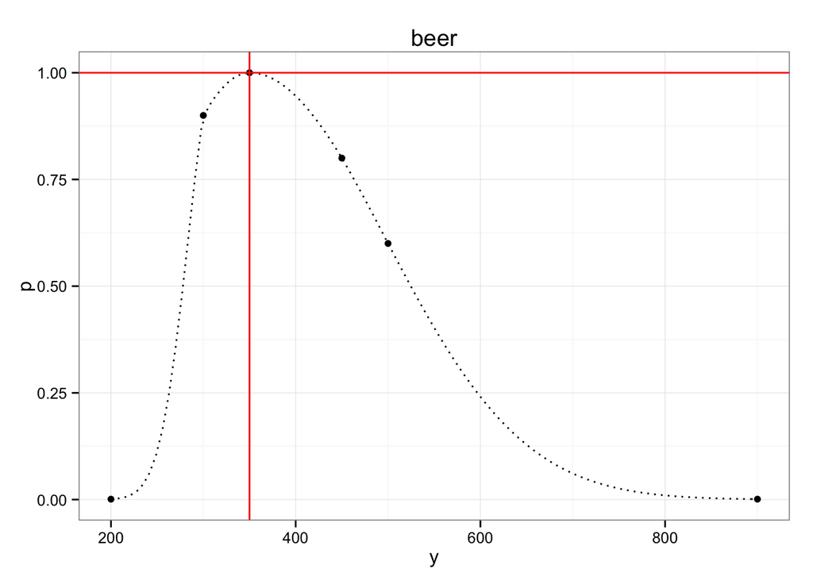

```r
item.plot(beer, "yp", 0)
```

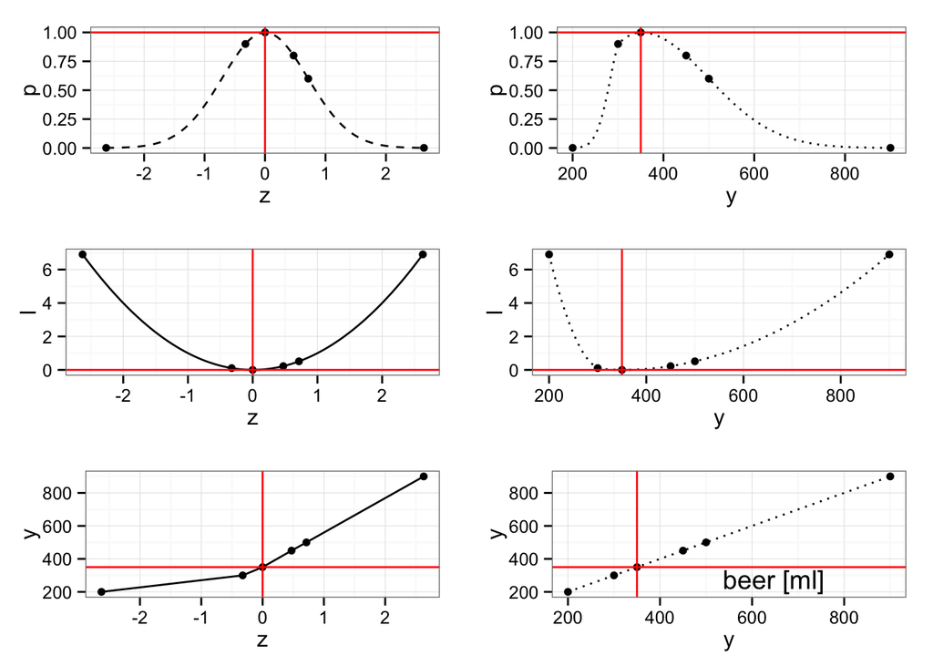

```r
item.plot(beer, "all", 0)
```

The pane $(1, 2)$ is the same as the previous graph. By taking its logarithm and flipping it upside down, it is transformed into the graph in pane $(2, 2)$, which is the loss version $(y, \ell)$ of $(y, p)$. The pane $(3, 2)$ is just the identity transformation $y \mapsto y$. The pane $(3, 1)$ is the crucial piecewise linear bijection $z \mapsto y$. With this transformation the pane $(2, 1)$ is mapped to the pane $(2, 2)$, and the pane $(1, 1)$ is mapped to the pane $(1, 2)$.

Since pane $(1, 1)$ is essentially the normal density, the least squares may be invoked whose subloss function is the quadratic function in pane $(2, 1)$. Note that graphs in panes $(1, 2)$ and $(2, 2)$ are not differentiable at the node points. Since the causality `caus` is given in terms of $y$ rather than $z$, for each iteration in optimization of $\mathrm{p}(z)$ or equivalently $\mathrm{\ell}(z)$ you need the transformation $z \stackrel{\beta}{\mapsto} y \stackrel{\mathrm{f}}{\mapsto} y \stackrel{\beta^{-1}}{\mapsto} z$ where $\beta$ is the piecewise linear bijection in pane $(3, 1)$. This implies that the optimization method should rely only to the subgradient rather than the gradient.

All other items have similar structures as will be illustrated subsequently.

### 2.2.2 Peanuts

```r
peanuts      <- template.item("peanuts")
peanuts$unit <- "[g]"
peanuts$tab  <- data.frame(y = c(   3, 15, 50  ),
                           p = c(rare,  1, rare))
peanuts$caus <- f(y, y["peanuts"])
peanuts      <- init.item(peanuts)
print.item(peanuts)
```

```
## peanuts [g]
##    y     z p    l a0    a1
## 1  3 -2.63 0 6.91 15  4.57
## 2 15  0.00 1 0.00 15 13.32
## 3 50  2.63 0 6.91 NA    NA
## caus = function (y)
## y["peanuts"]
```

The causality is again $y_{\text{peanuts}} := y_{\text{peanuts}} \quad \text{[g]}$

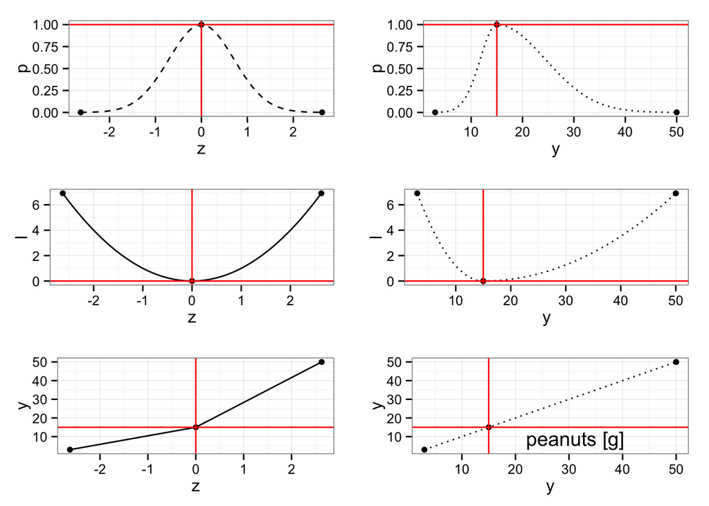

```r
item.plot(peanuts, "all", 0)
```

### 2.2.3 Beer to peanuts ratio

```r
ratio <- template.item("ratio")
ratio$unit <- "[ml/g]"
#ratio$grade <- TRUE
ratio$tab <- data.frame(y = c(   7, 350/15,   40),
                        p = c(rare,      1, rare))
ratio$caus <- f(y, y["beer"]/y["peanuts"])
ratio <- init.item(ratio)
print.item(ratio)
```

```
## ratio [ml/g]
##       y     z p    l    a0   a1
## 1  7.00 -2.63 0 6.91 23.33 6.21
## 2 23.33  0.00 1 0.00 23.33 6.34
## 3 40.00  2.63 0 6.91    NA   NA
## caus = function (y)
## y["beer"]/y["peanuts"]
```

This time the causality is $y_{\text{ratio}} := \frac{y_{\text{beer}}}{y_{\text{peanuts}}} \quad \text{[ml/g]}$ Although the most desirable ratio is 350 ml beer for 15 g peanuts, this is slack since any ratio from 7/1 to 40/1 is acceptable.

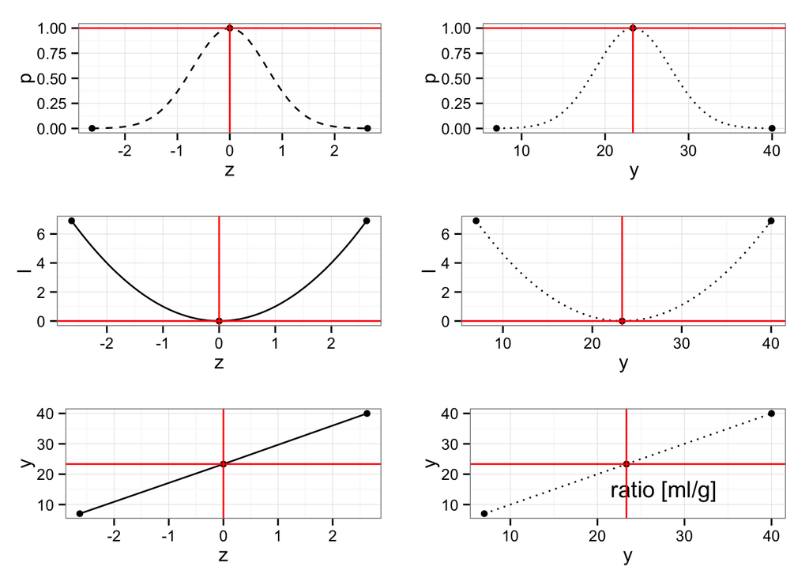

```r
item.plot(ratio, "all", 0)
```

### 2.2.4 Cost

```r
cost      <- template.item("cost")
cost$unit <- "[yen]"
#cost$grade <- TRUE
cost$tab  <- data.frame(y = c(   0, 200, 800, 900, 950 ),
                        p = c(rare,   1,  .8,  .3, rare))
cost$caus <- function(y, const = 200,
                      beer_price = 100/100, peanuts_price = 300/50) {
    const + beer_price*y["beer"] + peanuts_price*y["peanuts"]}
cost      <- init.item(cost)
print.item(cost)
```

```
## cost [yen]
##     y     z   p    l     a0      a1
## 1   0 -2.63 0.0 6.91 200.00   76.10
## 2 200  0.00 1.0 0.00 200.00 1270.16
## 3 800  0.47 0.8 0.22 724.40  160.03
## 4 900  1.10 0.3 1.20 864.17   32.66
## 5 950  2.63 0.0 6.91     NA      NA
## caus = function(y, const = 200,
##                       beer_price = 100/100, peanuts_price = 300/50) {
##     const + beer_price*y["beer"] + peanuts_price*y["peanuts"]}
```

The causality `caus` for the cost depends on the two independent variables `beer` and `peanuts`. The fixed cost for serving is 200 yen, with the rest proportional to the quantities of `beer` and `peanuts`.

$y_{\text{cost}} := \text{const} + \text{beer_price} \times y_{\text{beer}} + \text{peanuts_price} \times y_{\text{peanuts}} \quad \text{[yen]} \\ \text{const} := 200 \quad \text{[yen]} \\ \text{beer_price} := \frac{100}{100} = 1 \quad \text{[yen/ml]} \\ \text{peanuts_price} := \frac{300}{50} = 6 \quad \text{[yen/g]}$

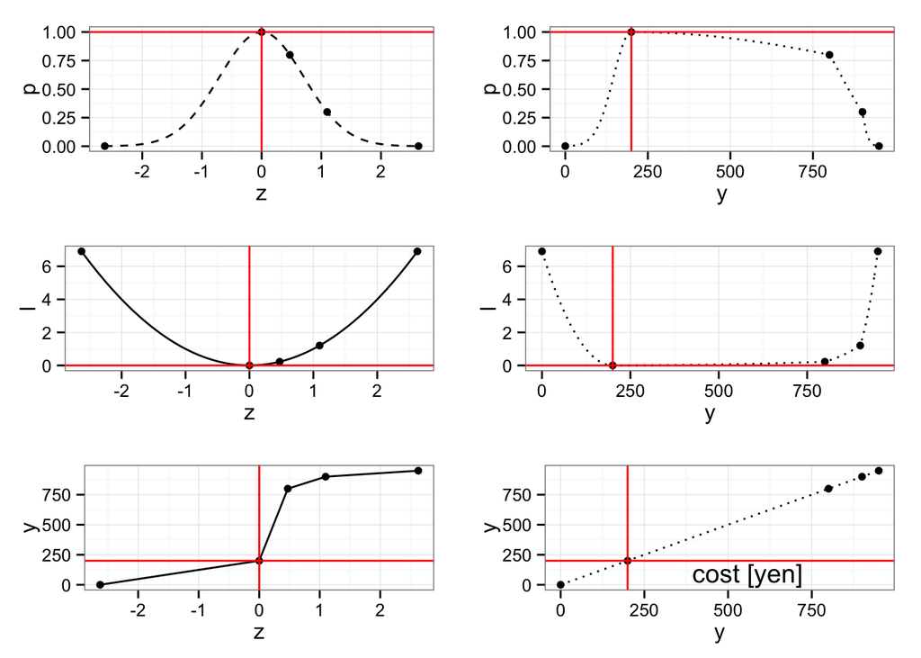

```r
item.plot(cost, "all", 0)
```

### 2.2.5 Energy

```r
energy      <- template.item("energy")
energy$unit <- "[kcal]"
#energy$grade <- TRUE
energy$tab  <- data.frame(y = c(   0, 50, 100, 200, 250, 300 ),
                          p = c(rare, .9,   1,  .5, .15, rare))
energy$caus <- function(y, per_beer_ml = 142/350, per_peanuts_g = 592/100) {
    per_beer_ml*y["beer"] + per_peanuts_g*y["peanuts"]}
energy      <- init.item(energy)
print.item(energy)
```

```
## energy [kcal]
##     y     z    p    l     a0     a1
## 1   0 -2.63 0.00 6.91  57.05  21.70
## 2  50 -0.32 0.90 0.11 100.00 154.04
## 3 100  0.00 1.00 0.00 100.00 120.11
## 4 200  0.83 0.50 0.69 123.59  91.78
## 5 250  1.38 0.15 1.90 194.95  39.97
## 6 300  2.63 0.00 6.91     NA     NA
## caus = function(y, per_beer_ml = 142/350, per_peanuts_g = 592/100) {
##     per_beer_ml*y["beer"] + per_peanuts_g*y["peanuts"]}
```

$y_{\text{energy}} := \text{beer_energy} \times y_{\text{beer}} + \text{peanuts_energy} \times y_{\text{peanuts}} \quad \text{[kcal]} \\ \text{per_beer_ml} := \frac{142}{350} \approx 0.406 \quad \text{[kcal/ml]} \\ \text{per_peanuts_g} := \frac{592}{100} = 5.92 \quad \text{[kcal/g]}$

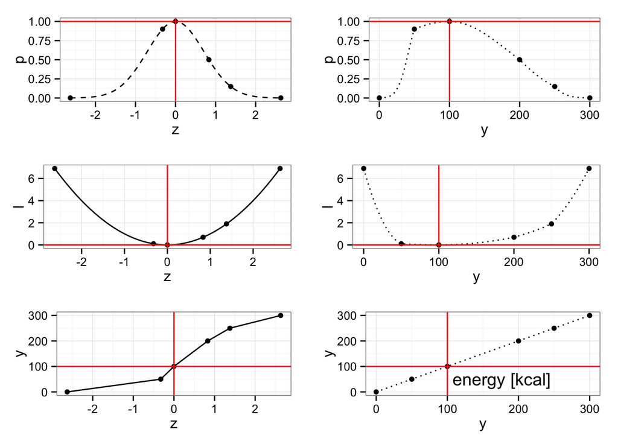

```r
item.plot(energy, "all", 0)
```

# 3 Arrange the basket

A basket is a set of items. If an item is in a basket, it is used as a part of the model; otherwise the item is excluded.

```r
beerpeanuts <- list(beer = beer, peanuts = peanuts,
                    ratio = ratio, cost = cost, energy = energy)
class(beerpeanuts) <- "basket"
```

In this case, all items are included into the basket. The basket’s name is `beerpeanuts`.

## 3.1 Independent variables

From within the basket, choose independent variables.

```r
ind <- c("beer", "peanuts")
```

These items must have the identity causality: the cause is by itself the outcome. Check `beer$caus` and `peanuts$cause` to verify.

## 3.2 Residue functions

The residual function is defined by `resfun.basket` which takes `z_ind` and the basket name as arguments. Depending on the optimization software, the residue function `resfun` to be passed to the optimization must be defined with single variable `z_ind`. Also, to draw a contour you need a two-variable residue function which is `resfun` with some of the independent variables fixed. For convenience, the two function `resfun` and `resfun2` are defined herein.

```r
resfun <- f(z_ind, resfun.basket(z_ind, beerpeanuts))
resfun2 <- f(x, y, resfun(c(x, y))) # resfun in 2 vars to plot contour
```

In this case there is no need to fix any of the independent variables `ind` since there are only two, `beer` and `peanuts` to begin with.

## 3.3 Initial values

The optimization is performed in normalized variables `z` rather than in the original amounts `y`. So their initial values are given in `z` rather than `y`.

```r
zs <- c(beer = 0.7, peanuts = 0.4, ratio = 0, cost = 0.3, energy = 0.4)
    # global var
```

If you hve no plausible initial values try starting with all items $=0$.

# 4 Solve

```r
(res1.optim <- optim(rep(0, length(ind)),
                    function(ind) loss.basket(ind, beerpeanuts)))
```

```
## $par
## [1] -0.3245929 -0.3865927
##
## $value
## [1] 1.049854
##
## $counts
## function gradient
##       99       NA
##
## $convergence
## [1] 0
##
## $message
## NULL
```

You could also try `nls` as well which is the default nonlinear least squares, but a better candidate would be `nlfb` in `nlmrt` library which is expected to be slower but more robust.

```r
install_load("nlmrt")
(res1.nlfb <- nlfb(rep(0, length(ind)), resfun,
                  lower = -5, upper = 5, trace = FALSE))
```

```
## nlmrt class object: x
## residual sumsquares =  1.0499  on  5 observations
##     after  24    Jacobian and  49 function evaluations
##   name            coeff          SE       tstat      pval      gradient    JSingval
## NULL     -0.324593        0.3347    -0.9697     0.4037     0.05546       2.456
## NULL     -0.380954        0.4474    -0.8515     0.4571     0.01459       1.173
```

This version is with a home-brew coodrinate descent method `armcd`; the advantage being simple implementation. Since `trace` is set to `TRUE`, it produces the trace of iterations: `beer`, `peanuts`, and `P` where $P$ is an indication of total desirability; nonnegative, usually less than or equal to one, and the bigger the better.

```r
(res1.cd <- armcd(c(1, 2), beerpeanuts, trace = TRUE))
```

```
##     beer  peanuts        P
## -0.32459 -0.38095  0.34996
##     beer  peanuts        P
## -0.32459 -0.38665  0.34999
##     beer  peanuts        P
## -0.32457 -0.38665  0.34999
##     beer  peanuts        P
## -0.32457 -0.38663  0.34999
```

```
## $z
##     beer  peanuts    ratio     cost   energy
## -0.32457 -0.38663 -0.10707  0.29871  0.83327
##
## $P
## [1] 0.34999
##
## $delta
## [1] 1.9877e-05
##
## $iters
## [1] 2
```

`$z` here show the optimal `z` values. `$P` is the desirability, which may be interpreted as the probability that this combination of `$z` will actually be put into action by the decision maker.

# 5 Report

Before doing anything else, save the present value of `zs` which contains the solution:

```r
(zs1.cd <- zs)
```

```
##     beer  peanuts    ratio     cost   energy
## -0.32457 -0.38663 -0.10707  0.29871  0.83327
```

More visually,

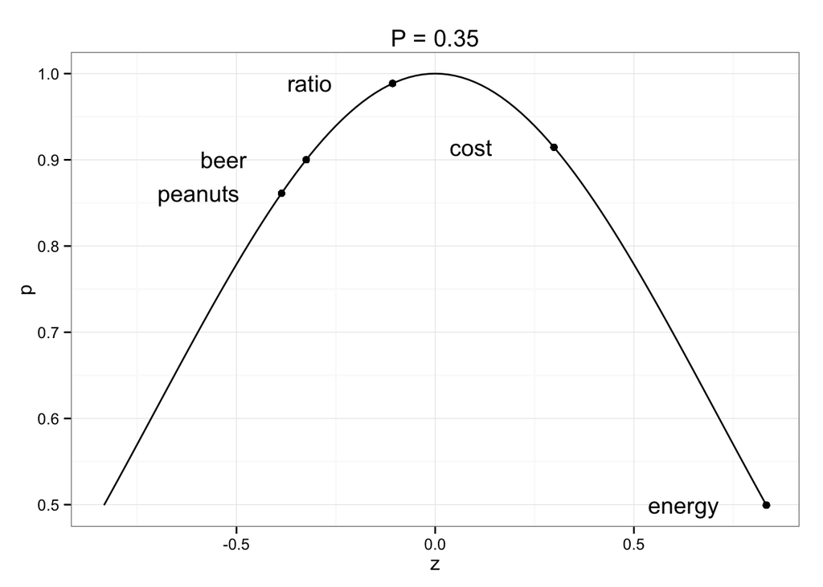

```r
p.plot(zs1.cd)
```

which shows that the `energy` is the most unsatisfactory among the items by being much more than the ideal amount.

Since there are only two independent variables `beer` and `peanuts`, the indifference curves may be illustrated as:

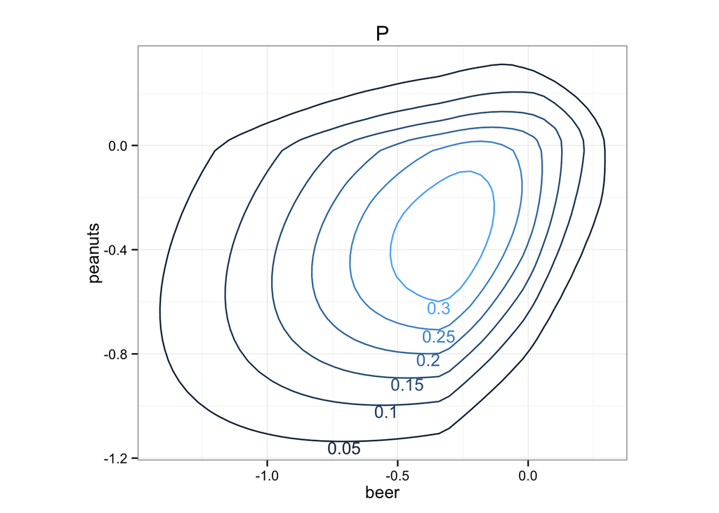

```r
#contour()
contour(150,150)
```

The values given in normalized variables $z$ may be converted into the original measurement units by

```r
round(y.basket(zs1.cd,beerpeanuts))
```

```
##    beer peanuts   ratio    cost  energy
##     300      13      23     579     200
```

# 6 Model revised

Now that we know `energy` to be the major source of frustration, we can try to change the beer to a half-calorie brand. The new `energy` would be:

```r
energy$caus <- function(y, per_beer_ml = 142/350/2, per_peanuts_g = 592/100) {
    per_beer_ml*y["beer"] + per_peanuts_g*y["peanuts"]}
energy <- init.item(energy)

beerpeanuts2 <- list(beer = beer, peanuts = peanuts, ratio = ratio, cost = cost, energy = energy)
resfun <- function(z_ind) {resfun.basket(z_ind, beerpeanuts2)}
```

```r
(res2.cd <- armcd(c(1, 2), beerpeanuts2, trace = FALSE))
```

```
## $z
##      beer   peanuts     ratio      cost    energy
## -0.109539 -0.136612 -0.025961  0.330182  0.438628
##
## $P
## [1] 0.71695
##
## $delta
## [1] 5.2391e-05
##
## $iters
## [1] 11
```

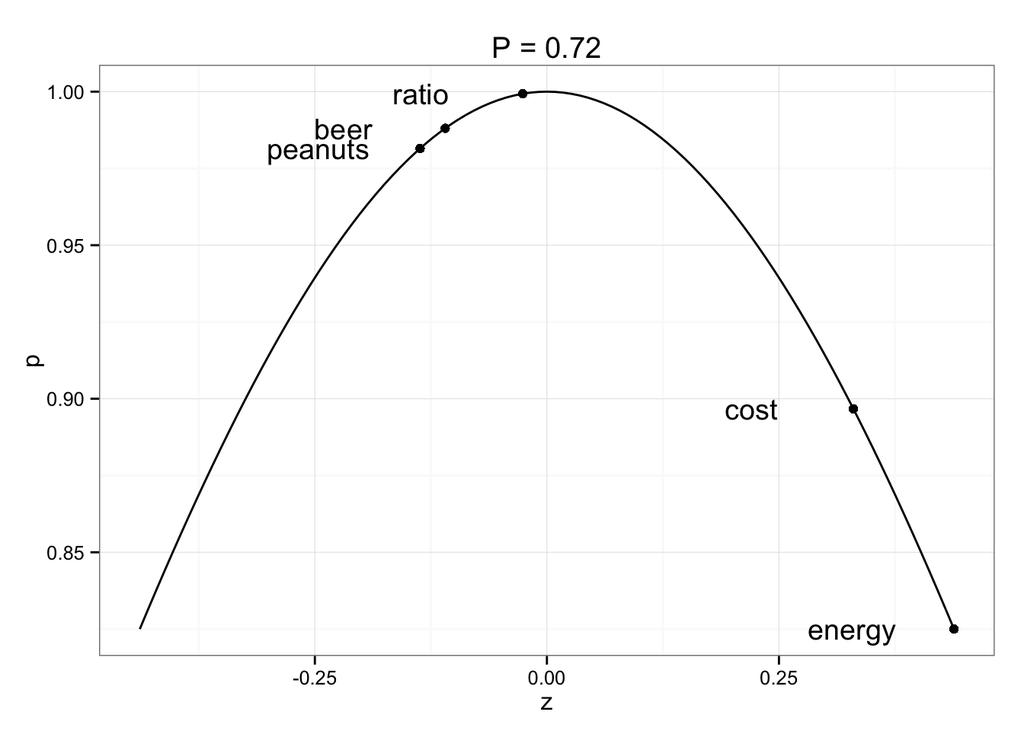

```r
zs2.cd <- zs
p.plot(zs2.cd)
```

```r
round(y.basket(zs2.cd, beerpeanuts2))
```

```
##    beer peanuts   ratio    cost  energy
##     333      14      23     619     153
```

The `energy` remains to be the greatest source of frustration. Although the consumption of beer increases only by 11%, the action probability $P$ jumps up from 0.35 to 0.72.

This model assumes that there is no difference in taste between the normal and half-calorie beers, which is actually unlikely. Inclusion of taste as an outcome would make the model more realistic, in which case a relationship between energy and taste would be needed.